# DATA 624 - PROJECT 1

### ARIMA with Box Cox Adjustment

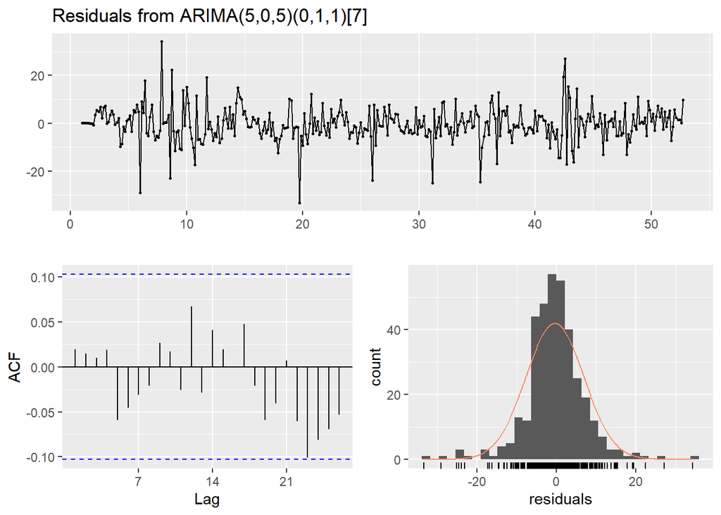

```
##
##  Ljung-Box test
##
## data:  Residuals from ARIMA(5,0,5)(0,1,1)[7]
## Q* = 6.2679, df = 3, p-value = 0.09928
##
## Model df: 11.   Total lags used: 14
```

```r
atm2_lambda = BoxCox.lambda(ATM2)
atm2_box_arima_fit <-  Arima(ATM2, order = c(5, 0, 5), seasonal = c(0, 1, 1), lambda = atm2_lambda)
checkresiduals(atm2_box_arima_fit)
```

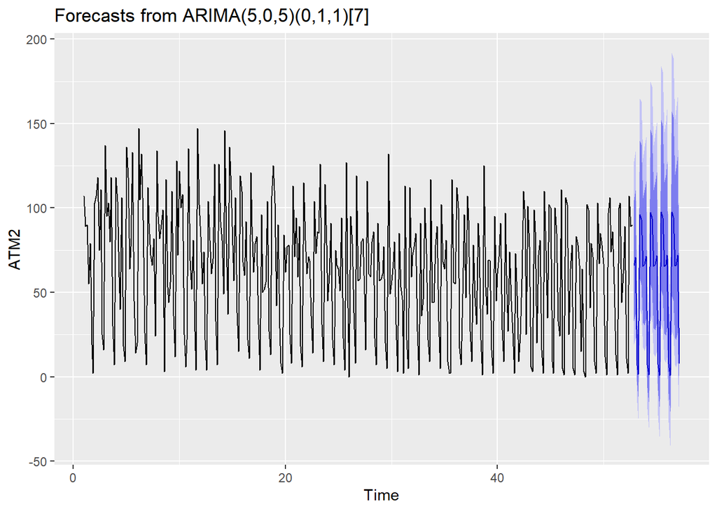

```r
atm2_box_arima_fit%>% forecast(h=31) %>% autoplot()
```

```r
kpss.test(resid(atm2_box_arima_fit))
```

```
##
##  KPSS Test for Level Stationarity
##
## data:  resid(atm2_box_arima_fit)
## KPSS Level = 0.11532, Truncation lag parameter = 5, p-value = 0.1
```

### MODEL EVALUATION

I will use the `tsCV` function and evaluate the models.My goal is to find the model that produces minumum RMSE.

```r
h <- 31
get_rmse <- function(error) {
  sqrt(mean(error^2, na.rm = TRUE))
}
atm2_arima_forecast <- function(x, h) {
  forecast(Arima(x, order = c(2, 0, 2), seasonal = c(0, 1, 2)), h = h)
}
atm2_arima_box_forecast <- function(x, h) {
  forecast(Arima(x, order = c(5, 0, 5), seasonal = c(0, 1, 1),lambda = atm2_lambda), h = h)
}

residuals_stl <- tsCV(ATM2, stlf, h = h, s.window = 7, robust = TRUE)
residuals_stl_arima <- tsCV(ATM2, stlf, h = h, s.window = 7, robust = TRUE, method = "arima")
residuals_hw <- tsCV(ATM2, hw, h = h)
residuals_arima <- tsCV(ATM2, atm2_arima_forecast, h = h)
residuals_arima_box <- tsCV(ATM2, atm2_arima_box_forecast, h = h)
data.frame(Model_Name = c("STL", "STL & ARIMA", "Holt-Winters", "ARIMA","ARIMA-BOX_COX"),
           RMSE = c(get_rmse(residuals_stl[, h]), get_rmse(residuals_stl_arima[, h]), get_rmse(residuals_hw[, h]), get_rmse(residuals_arima[, h]),
                                                                                                                        get_rmse(residuals_arima_box[, h]))) %>%
  arrange(RMSE) %>%
  kable() %>%
  kable_styling()
```

| Model_Name | RMSE |
| --- | --- |
| ARIMA | 39.69270 |
| ARIMA-BOX_COX | 41.24307 |
| STL & ARIMA | 44.05280 |
| STL | 44.59259 |
| Holt-Winters | 58.72761 |

The ARIMA(2, 0, 2)(0, 1, 2) model gives the minumum RMSE among the other models.The residuals appear to be approximately normally distributed with a mean around zero.

### ATM #3

#### Data Cleanup

The ATM#3 data is quite challenging data as seen below since most of values are zero.

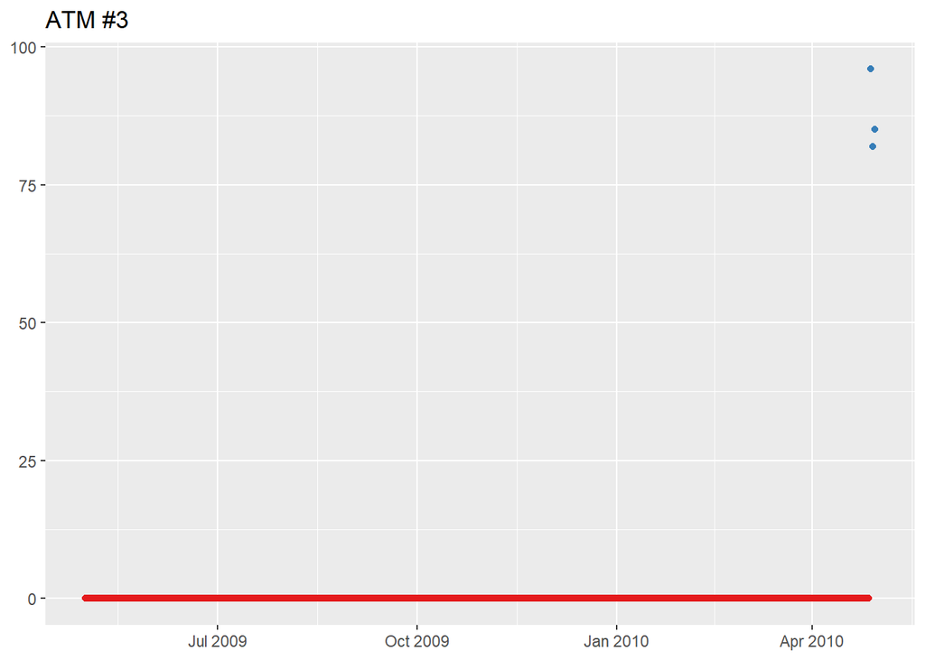

```r
atm_data %>%
  filter(ATM == "ATM3") %>%
  mutate(nonzero = if_else(Cash == 0, "No", "Yes")) %>%
  ggplot(aes(DATE, Cash, color = nonzero)) +
  geom_point() +
  ggtitle("ATM #3") +
  scale_color_brewer(palette = "Set1") +
  theme(axis.title = element_blank(), legend.position = "none")
```

#### Model Creation

I will be using mean value for ATM3 data since we only have three observations.

#### Mean of Observations

```r
atm3 <- atm_data %>%
  filter(ATM == "ATM3", Cash > 0)
atm3_mean <- mean(atm3$Cash)
```

### ATM #4

#### Data Cleanup

The ATM#4 also challenging, however it is not as bad as ATM #3 data.

```r
atm4 <- atm_data %>%
  filter(ATM == "ATM4")
```

Here, I’d like to review the “atm4” timeseries data to determine whether there is a seosanality and ACF and PACF plots.

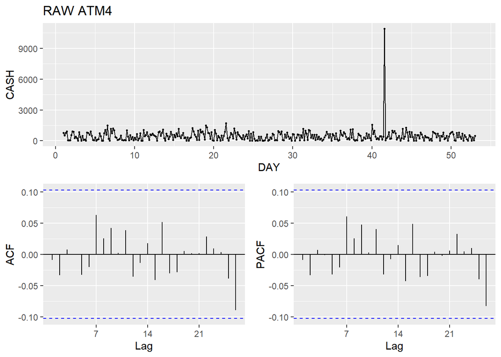

```r
ATM4 <- atm_data[atm_data$ATM == "ATM4",]
ATM4 <- ATM4[complete.cases(ATM4),]
ATM4 <- ts(ATM4[c("Cash")],frequency = 7)
ggtsdisplay(ATM4,
            main = "RAW ATM4",
            xlab = "DAY",
            ylab = "CASH")
```

I will check Seasonality and Outlier for atm4 data.

#### Outlier and Seasonality

[figure not shown]

```r
atm4$weekday <- factor(weekdays(as.Date(atm4$DATE)))
atm4$weekday <- ordered(atm4$weekday,levels = c("Mon","Tues","Wedn","Thurs","Fri","Satur","Sun"))
#drop NaN values
atm4 <- atm4[complete.cases(atm4),]
ggplot(atm4[complete.cases(atm4),],aes(x=weekday,y=Cash,color=ATM))+
  geom_boxplot()+
  ggtitle("ATM #4 OUTLIER/SEASONALTY PLOT")
```

#### Model Creation

I will use following forecating models on this time series and determine which one is better by estimatin error metric RMSE. I will use time series cross validation function to estimate RMSE for timeseries data.

- Seasonal and Trend decomposition (STL)
- Seasonal and Trend decomposition (STL) with ARIMA
- Holt-Winters
- Holt-Winters with Box Cox Adjustment
- ARIMA
- ARIMA with Box Cox Adjustment

```r
ATM4 <- atm_data[atm_data$ATM == "ATM4",]
ATM4 <- ATM4[complete.cases(ATM4),]
ATM4 <- ts(ATM4[c("Cash")],frequency = 7)
Box.test(diff(ATM4,lag=7), type = "Ljung-Box")
```

```
##
##  Box-Ljung test
##
## data:  diff(ATM4, lag = 7)
## X-squared = 0.081947, df = 1, p-value = 0.7747
```

```r
kpss.test(diff(ATM4,lag=7))
```

```
##
##  KPSS Test for Level Stationarity
##
## data:  diff(ATM4, lag = 7)
## KPSS Level = 0.014025, Truncation lag parameter = 5, p-value = 0.1
```

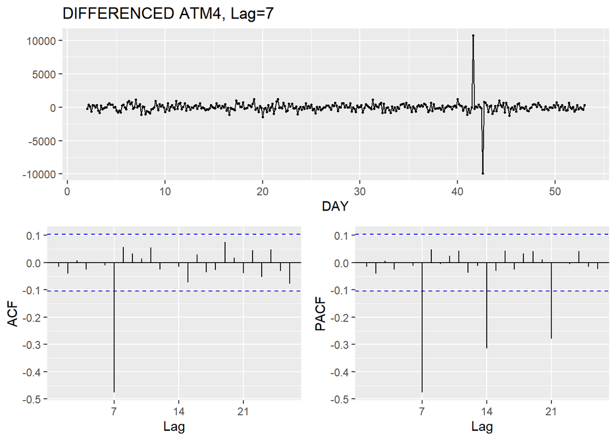

```r
ggtsdisplay(diff(ATM4,lag=7),
            main = "DIFFERENCED ATM4, Lag=7",
            xlab = "DAY",
            ylab = "")
```

#### Seasonal and Trend decomposition (STL)

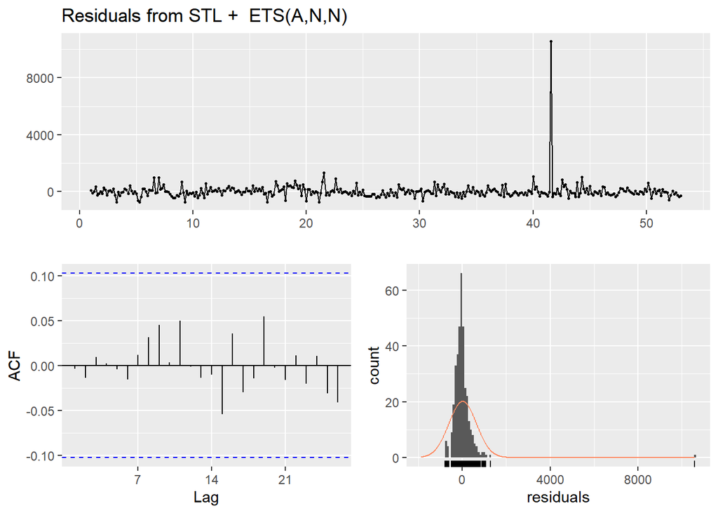

```
##
##  Ljung-Box test
##
## data:  Residuals from STL +  ETS(A,N,N)
## Q* = 2.4559, df = 12, p-value = 0.9983
##
## Model df: 2.   Total lags used: 14
```

```r
atm4_stl_fit <- ATM4 %>%
  stlf(h = 31, s.window = 7, robust = TRUE)
checkresiduals(atm4_stl_fit)
```

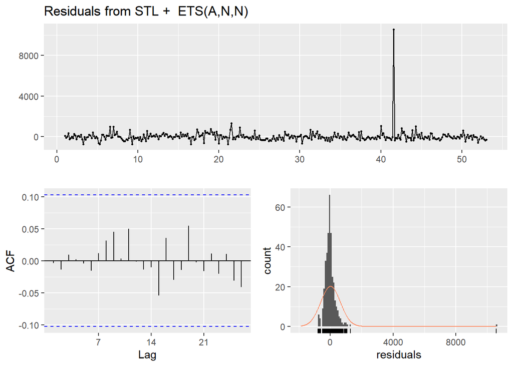

```
##
##  Ljung-Box test
##
## data:  Residuals from STL +  ETS(A,N,N)
## Q* = 2.4559, df = 12, p-value = 0.9983
##
## Model df: 2.   Total lags used: 14
```

```r
checkresiduals(atm4_stl_fit)
```

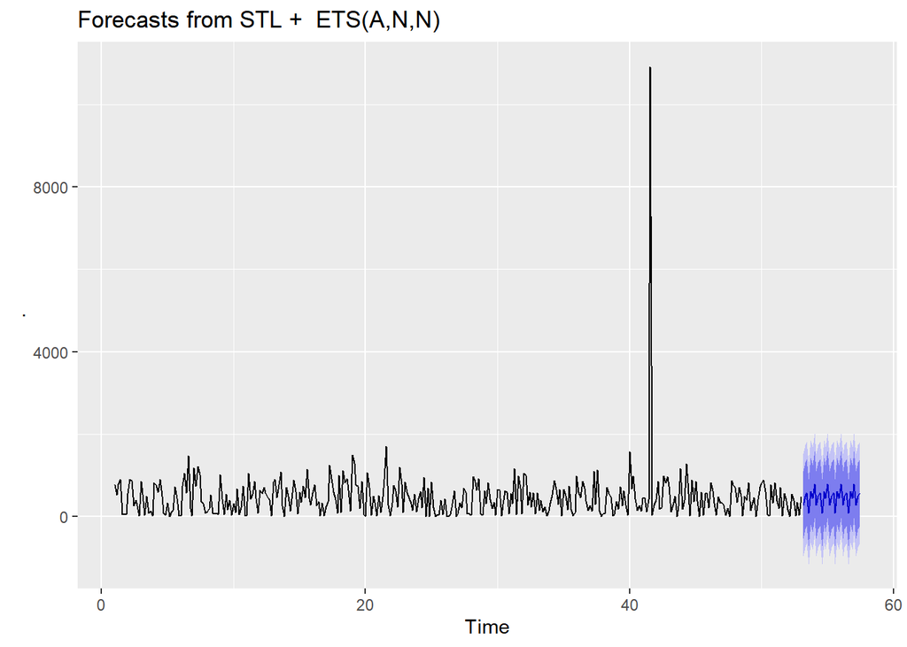

```r
atm4_stl_fit%>% forecast(h=31) %>% autoplot()
```

#### Seasonal and Trend decomposition (STL) with ARIMA

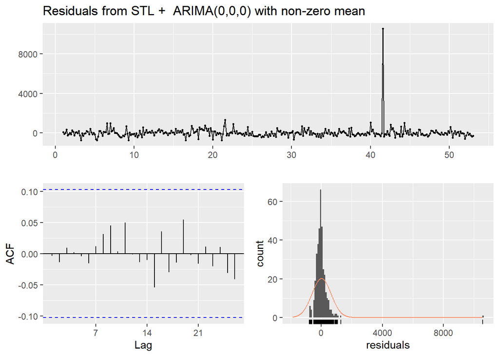

```
##
##  Ljung-Box test
##
## data:  Residuals from STL +  ARIMA(0,0,0) with non-zero mean
## Q* = 2.4561, df = 13, p-value = 0.9993
##
## Model df: 1.   Total lags used: 14
```

```r
atm4_stl_arima_fit <- ATM4 %>%
  stlf(h = 31, s.window = 7, robust = TRUE, method = "arima")
checkresiduals(atm4_stl_arima_fit)
```

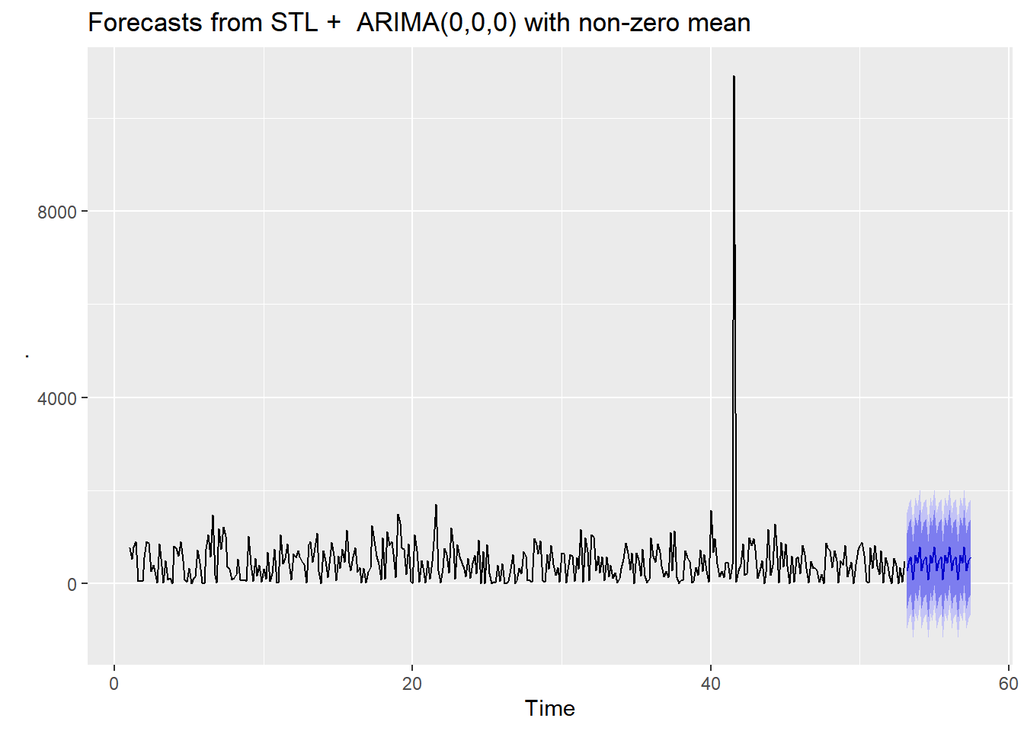

```r
atm4_stl_arima_fit%>% forecast(h=31) %>% autoplot()
```

#### Holt-Winters

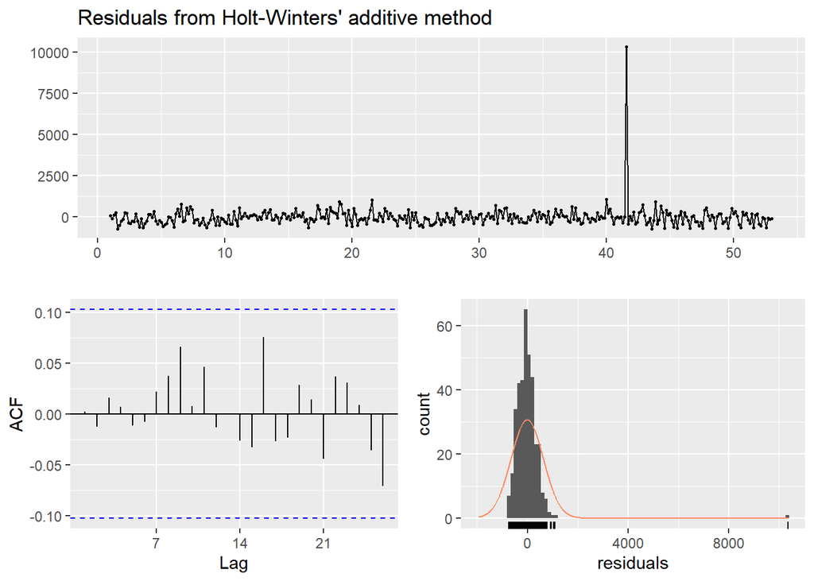

```
##
##  Ljung-Box test
##
## data:  Residuals from Holt-Winters' additive method
## Q* = 3.7364, df = 3, p-value = 0.2914
##
## Model df: 11.   Total lags used: 14
```

```r
atm4_hw_fit <- hw(ATM4, h = 31)
checkresiduals(atm4_hw_fit)
```

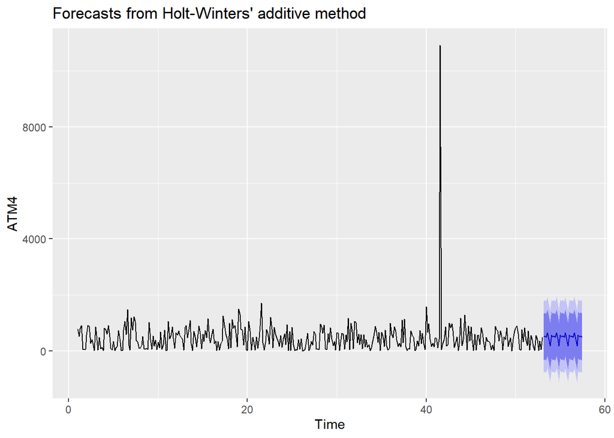

```r
atm4_hw_fit%>% forecast(h=31) %>% autoplot()
```

### Holt-Winters with Box Cox Adjustment

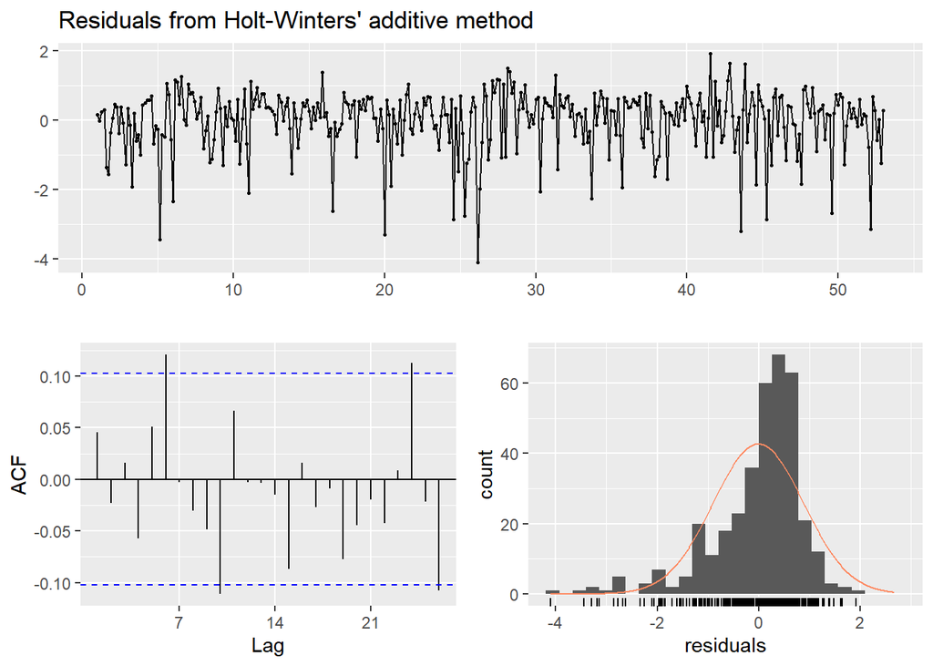

```
##
##  Ljung-Box test
##
## data:  Residuals from Holt-Winters' additive method
## Q* = 16.33, df = 3, p-value = 0.0009704
##
## Model df: 11.   Total lags used: 14
```

```r
atm4_lambda <- BoxCox.lambda(ATM4)
atm4_adj_hw_fit <- hw(ATM4, h = 31, lambda = atm4_lambda)
checkresiduals(atm4_adj_hw_fit)
```

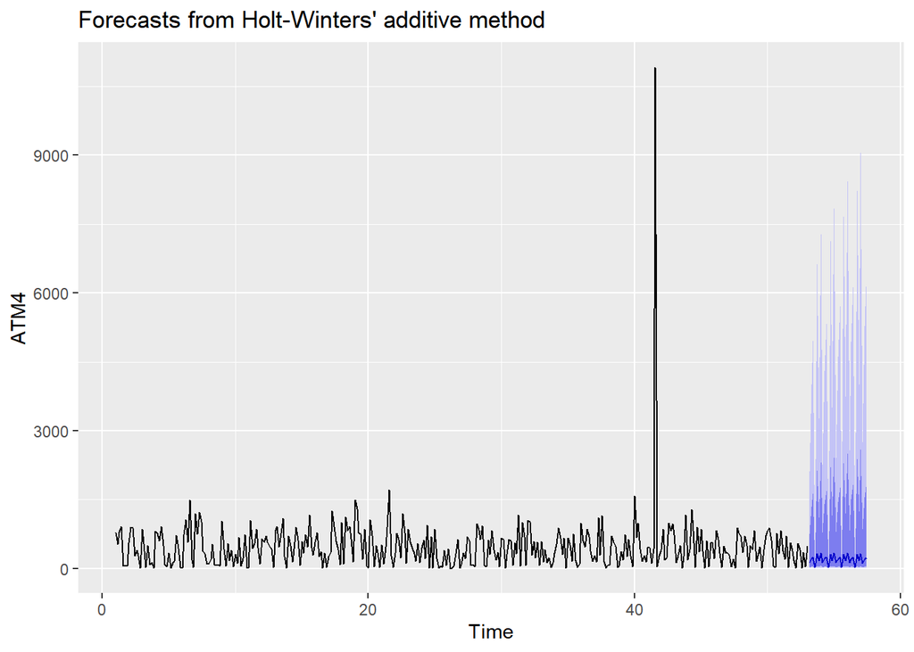

```r
atm4_adj_hw_fit%>% forecast(h=31) %>% autoplot()
```

#### ARIMA

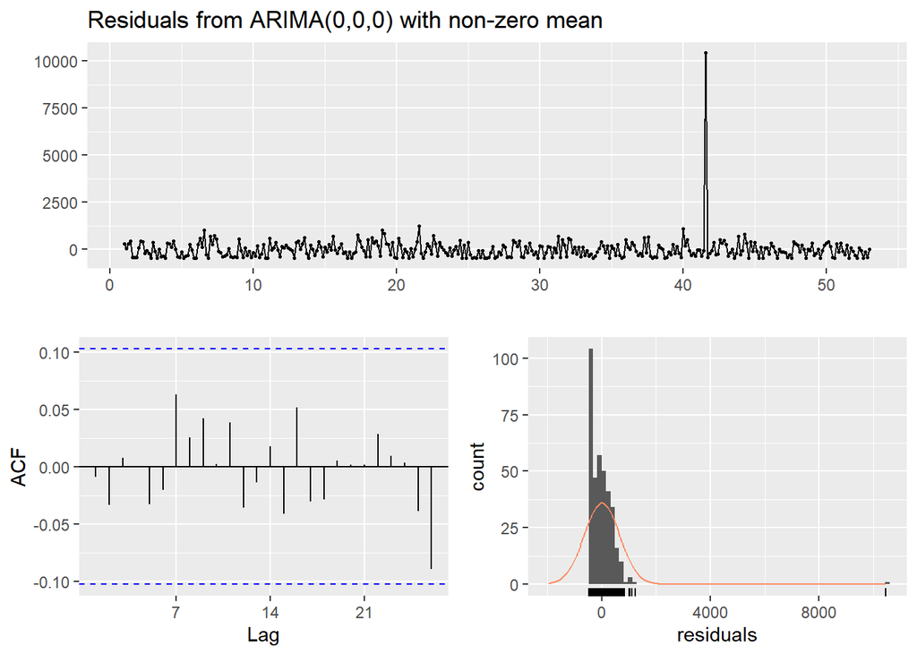

```
##
##  Ljung-Box test
##
## data:  Residuals from ARIMA(0,0,0) with non-zero mean
## Q* = 4.6668, df = 13, p-value = 0.9818
##
## Model df: 1.   Total lags used: 14
```

```r
atm4_arima_fit <- auto.arima(ATM4)
checkresiduals(atm4_arima_fit)
```

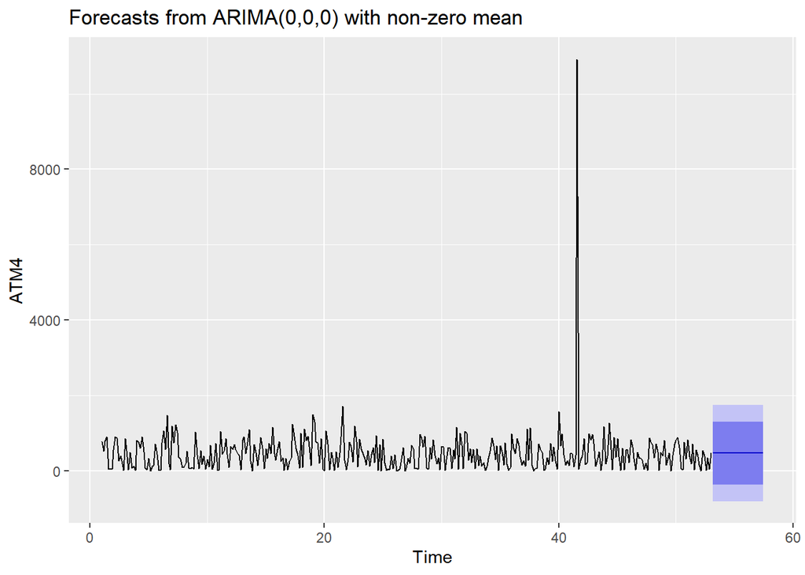

```r
atm4_arima_fit%>% forecast(h=31) %>% autoplot()
```

```r
kpss.test(resid(atm4_arima_fit))
```

```
##
##  KPSS Test for Level Stationarity
##
## data:  resid(atm4_arima_fit)
## KPSS Level = 0.079654, Truncation lag parameter = 5, p-value = 0.1
```

### ARIMA with Box Cox Adjustment

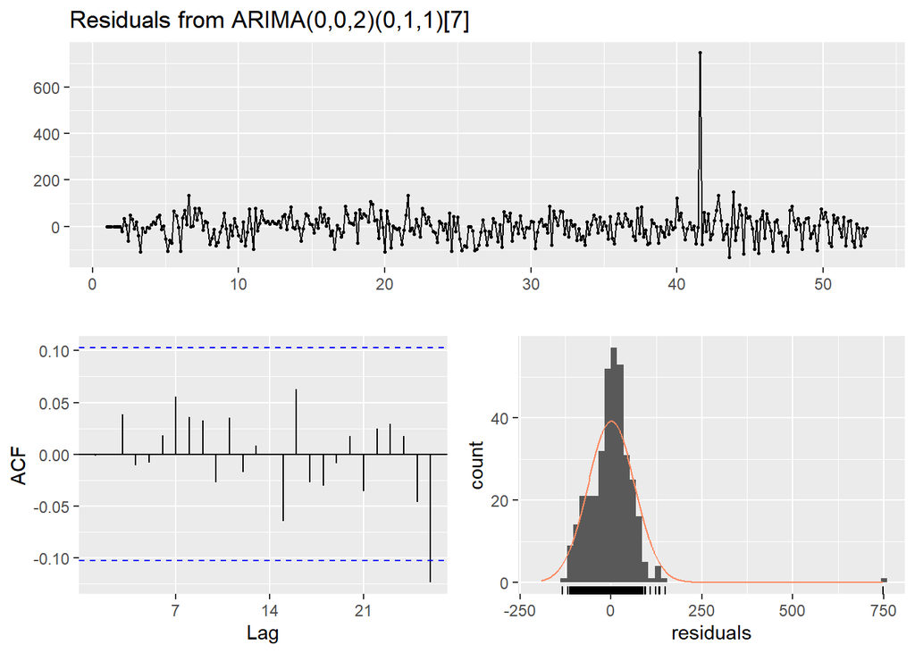

```
##
##  Ljung-Box test
##
## data:  Residuals from ARIMA(0,0,2)(0,1,1)[7]
## Q* = 3.6778, df = 11, p-value = 0.9784
##
## Model df: 3.   Total lags used: 14
```

```r
atm4_lambda = BoxCox.lambda(ATM4)
atm4_box_arima_fit <- Arima(ATM4, order = c(0, 0, 2), seasonal = c(0, 1, 1), lambda = atm2_lambda)
checkresiduals(atm4_box_arima_fit)
```

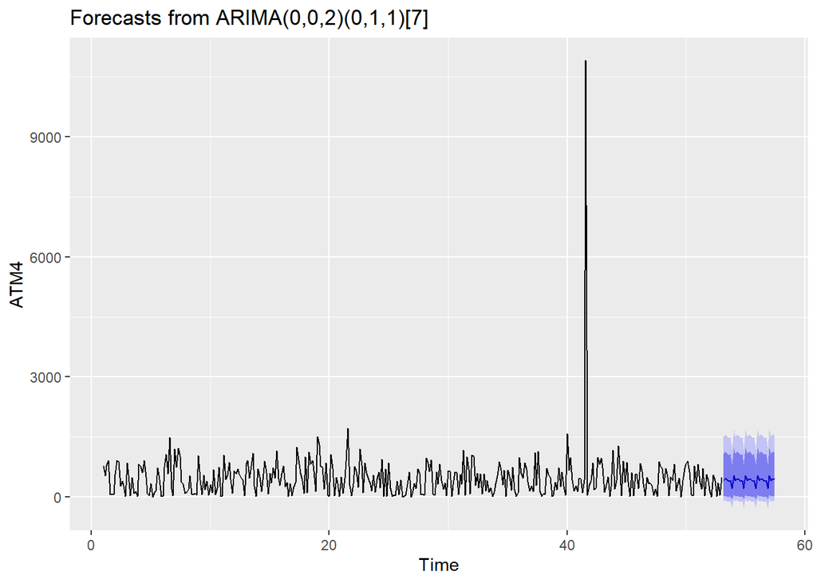

```r
atm4_box_arima_fit%>% forecast(h=31) %>% autoplot()
```

```r
kpss.test(resid(atm4_box_arima_fit))
```

```
##
##  KPSS Test for Level Stationarity
##
## data:  resid(atm4_box_arima_fit)
## KPSS Level = 0.074774, Truncation lag parameter = 5, p-value = 0.1
```

### MODEL EVALUATION

I will use the `tsCV` function and evaluate the models.My goal is to find the model that produces minumum RMSE.

```r
h <- 31
get_rmse <- function(error) {
  sqrt(mean(error^2, na.rm = TRUE))
}
atm4_arima_forecast <- function(x, h) {
  forecast(Arima(x, order = c(0, 0, 0)), h = h)
}
atm4_arima_box_forecast <- function(x, h) {
  forecast(Arima(x, order = c(0, 0, 2), seasonal = c(0, 1, 1),lambda = atm4_lambda), h = h)
}

residuals_stl <- tsCV(ATM4, stlf, h = h, s.window = 7, robust = TRUE)
residuals_stl_arima <- tsCV(ATM4, stlf, h = h, s.window = 7, robust = TRUE, method = "arima")
residuals_hw <- tsCV(ATM4, hw, h = h)
residuals_arima <- tsCV(ATM4, atm4_arima_forecast, h = h)
residuals_arima_box <- tsCV(ATM4, atm4_arima_box_forecast, h = h)
data.frame(Model_Name = c("STL", "STL & ARIMA", "Holt-Winters", "ARIMA","ARIMA-BOX_COX"),
           RMSE = c(get_rmse(residuals_stl[, h]), get_rmse(residuals_stl_arima[, h]), get_rmse(residuals_hw[, h]), get_rmse(residuals_arima[, h]),
                                                                                                                        get_rmse(residuals_arima_box[, h]))) %>%
  arrange(RMSE) %>%
  kable() %>%
  kable_styling()
```

| Model_Name | RMSE |
| --- | --- |
| ARIMA | 675.1356 |
| STL & ARIMA | 689.7695 |
| ARIMA-BOX_COX | 696.7529 |
| STL | 697.5947 |
| Holt-Winters | 777.7074 |

### SUMMARY

```r
atm1_forecast <- atm1_arima_fit %>% forecast(h=31)
atm2_forecast <- atm2_arima_fit %>% forecast(h=31)
atm3_forecast <- rep(atm3_mean, h=31)
atm4_forecast <- atm4_box_arima_fit %>% forecast(h=31)
atm_forecasts_df <- data.frame("DATE" = seq(ymd("2010-05-01"), ymd("2010-05-31"), by = "1 day"), "ATM" = c("ATM1"), "Cash" = c(atm1_forecast$mean))
atm_forecasts_df <- data.frame("DATE" = seq(ymd("2010-05-01"), ymd("2010-05-31"), by = "1 day"), "ATM" = c("ATM2"), "Cash" = c(atm2_forecast$mean)) %>%
  rbind(atm_forecasts_df, .)
atm_forecasts_df <- data.frame("DATE" = seq(ymd("2010-05-01"), ymd("2010-05-31"), by = "1 day"), "ATM" = c("ATM3"), "Cash" = atm3_forecast) %>%
  rbind(atm_forecasts_df, .)
atm_forecasts_df <- data.frame("DATE" = seq(ymd("2010-05-01"), ymd("2010-05-31"), by = "1 day"), "ATM" = c("ATM4"), "Cash" = c(atm4_forecast$mean)) %>%
  rbind(atm_forecasts_df, .)
atm_forecasts_df %>%
  kable() %>%
  kable_styling()
```

| DATE | ATM | Cash |
| --- | --- | --- |
| 2010-05-01 | ATM1 | 86.805607 |
| 2010-05-02 | ATM1 | 100.640560 |
| 2010-05-03 | ATM1 | 74.714560 |
| 2010-05-04 | ATM1 | 4.762634 |
| 2010-05-05 | ATM1 | 100.063192 |
| 2010-05-06 | ATM1 | 79.356704 |
| 2010-05-07 | ATM1 | 85.410706 |
| 2010-05-08 | ATM1 | 86.967155 |
| 2010-05-09 | ATM1 | 100.640560 |
| 2010-05-10 | ATM1 | 74.714560 |
| 2010-05-11 | ATM1 | 4.762634 |
| 2010-05-12 | ATM1 | 100.063192 |
| 2010-05-13 | ATM1 | 79.356704 |
| 2010-05-14 | ATM1 | 85.410706 |
| 2010-05-15 | ATM1 | 86.967155 |
| 2010-05-16 | ATM1 | 100.640560 |
| 2010-05-17 | ATM1 | 74.714560 |
| 2010-05-18 | ATM1 | 4.762634 |
| 2010-05-19 | ATM1 | 100.063192 |
| 2010-05-20 | ATM1 | 79.356704 |
| 2010-05-21 | ATM1 | 85.410706 |
| 2010-05-22 | ATM1 | 86.967155 |
| 2010-05-23 | ATM1 | 100.640560 |
| 2010-05-24 | ATM1 | 74.714560 |
| 2010-05-25 | ATM1 | 4.762634 |
| 2010-05-26 | ATM1 | 100.063192 |
| 2010-05-27 | ATM1 | 79.356704 |
| 2010-05-28 | ATM1 | 85.410706 |
| 2010-05-29 | ATM1 | 86.967155 |
| 2010-05-30 | ATM1 | 100.640560 |

[output cut: 94 more lines]

```r
write.csv(atm_forecasts_df,"atm_forecasts_df.csv")
```

## Part B - Forecasting Power

Part B consists of a simple dataset of residential power usage for January 1998 until December 2013. Your assignment is to model these data and a monthly forecast for 2014. The data is given in a single file. The variable ‘KWH’ is power consumption in Kilowatt hours, the rest is straight forward. Add this to your existing files above.

### Data Review-Missing values

```r
kable(tail(power_data))
```

| CaseSequence | YYYY-MMM | KWH |
| --- | --- | --- |
| 919 | 2013-Jul | 8415321 |
| 920 | 2013-Aug | 9080226 |
| 921 | 2013-Sep | 7968220 |
| 922 | 2013-Oct | 5759367 |
| 923 | 2013-Nov | 5769083 |
| 924 | 2013-Dec | 9606304 |

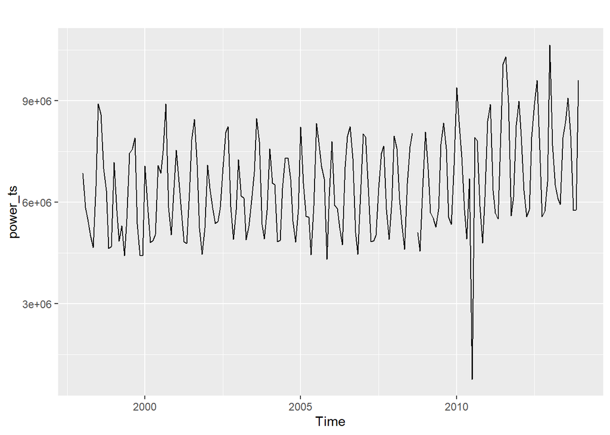

```r
power_ts <-power_data %>%
  select(KWH) %>%
  ts(start = decimal_date(date("1998-01-01")), frequency = 12)
autoplot(power_ts)
```

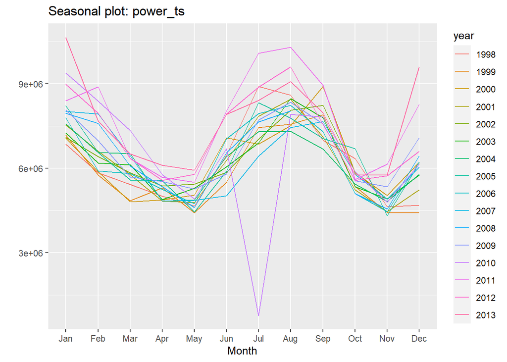

```r
ggseasonplot(power_ts)
```

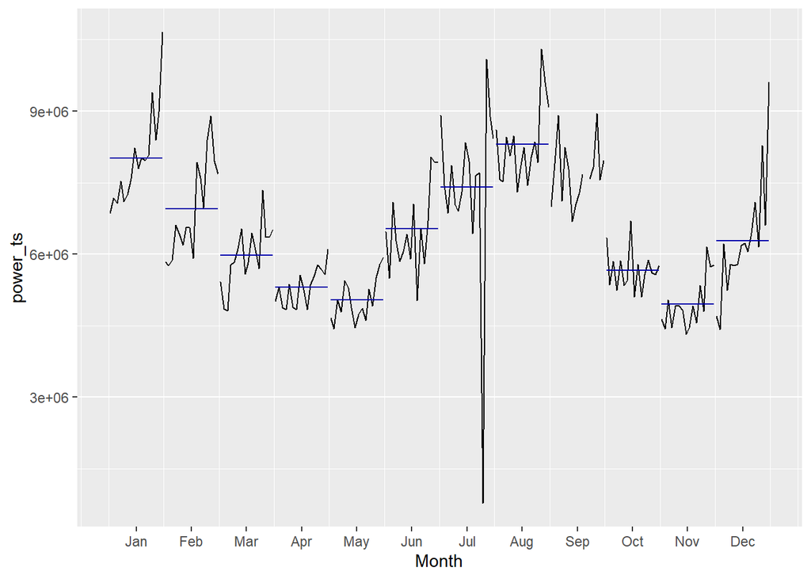

```r
ggsubseriesplot(power_ts)
```

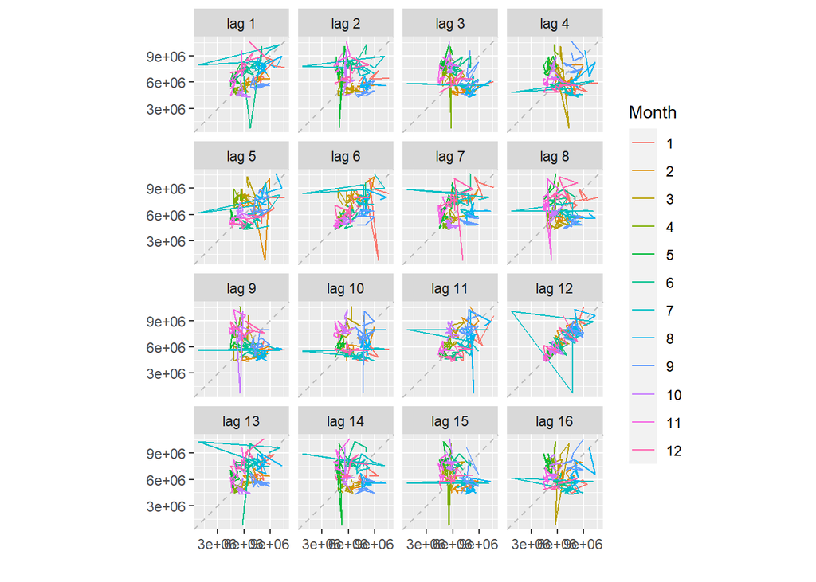

```r
gglagplot(power_ts)
```

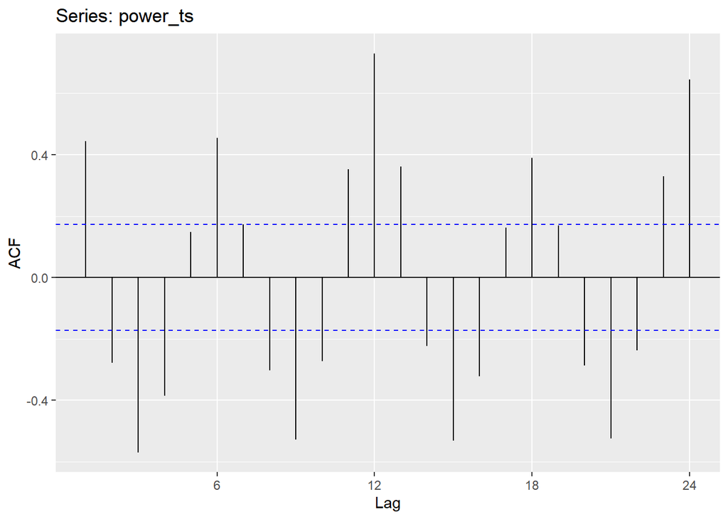

```r
ggAcf(power_ts)
```

The power_data contains 1 missing values on Sept 2008.The data also contains an extreme value in july 2010.ACF plot suggest that there is a sesonality in power_data.I possoble need to use lag=12 sesonality adjustment.

I will use `tsclean` package to clean the missing values and winsorize extreme value and replot the differents graphs.

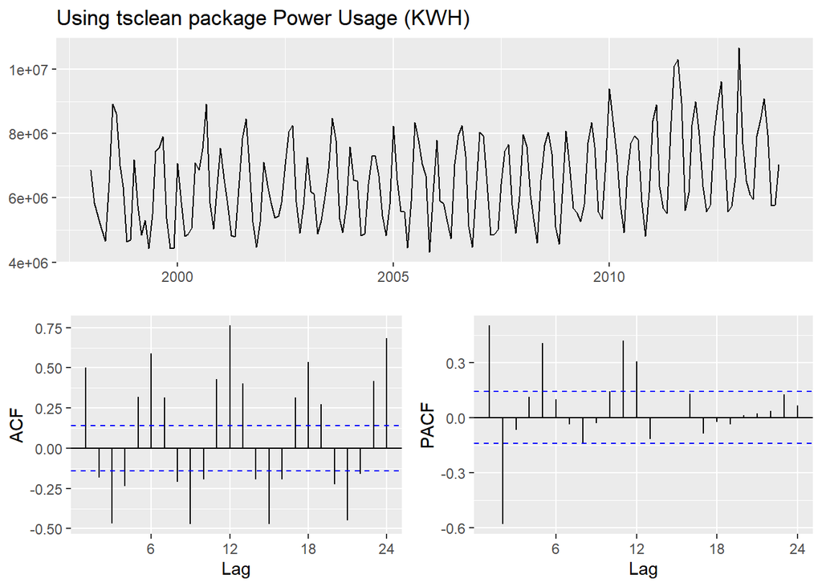

```r
power_ts <- tsclean(power_ts)
ggtsplot <- function(ts, title) {
  grid.arrange(
    autoplot(ts) +
      scale_y_continuous() +
      ggtitle(title) +
      theme(axis.title = element_blank()),
    grid.arrange(
      ggAcf(ts) + ggtitle(element_blank()),
      ggPacf(ts) + ggtitle(element_blank()), ncol = 2)
    , nrow = 2)
}
ggtsplot(power_ts, "Using tsclean package Power Usage (KWH)")
```

It is clearn that there is a seasonality in this data.

#### Model Creation

I will try to build a model that captures seasonality.

#### ARIMA with Box Cox Adjustment

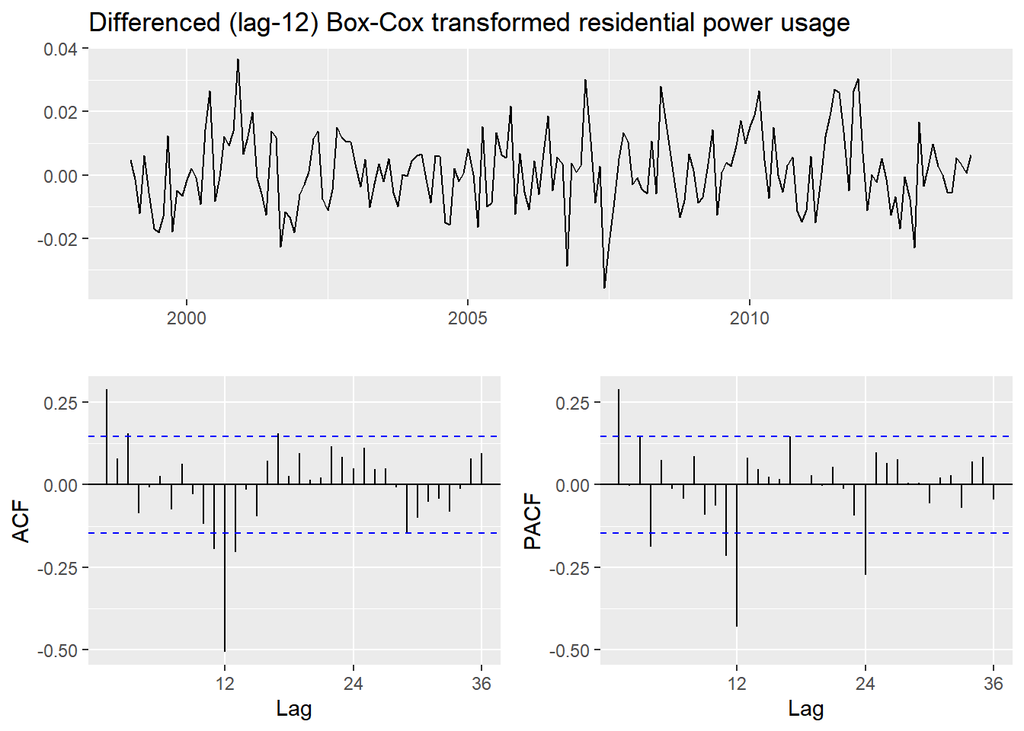

```r
power_ts <- tsclean(power_ts)
power_ts_lambda = BoxCox.lambda(power_ts)
power_ts_diff<-BoxCox(power_ts, power_ts_lambda)
ggtsdisplay(diff(power_ts_diff, 12), points = FALSE, main = "Differenced (lag-12) Box-Cox transformed residential power usage")
```

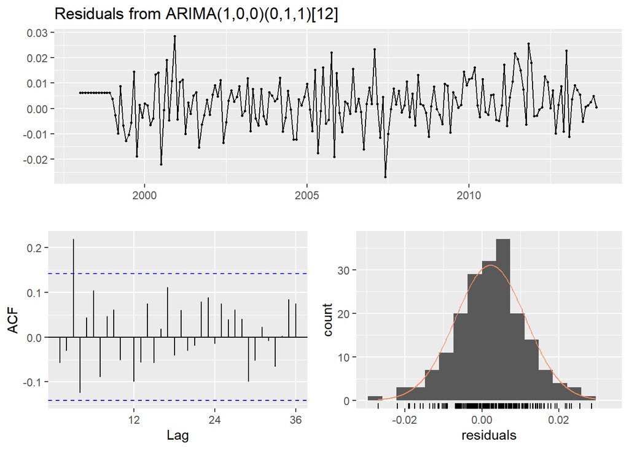

```
##
##  Ljung-Box test
##
## data:  Residuals from ARIMA(1,0,0)(0,1,1)[12]
## Q* = 31.099, df = 22, p-value = 0.0941
##
## Model df: 2.   Total lags used: 24
```

```r
power_ts_arima_fit <- Arima(power_ts, order = c(1, 0, 0), seasonal = c(0, 1, 1), lambda = power_ts_lambda)
checkresiduals(power_ts_arima_fit)
```

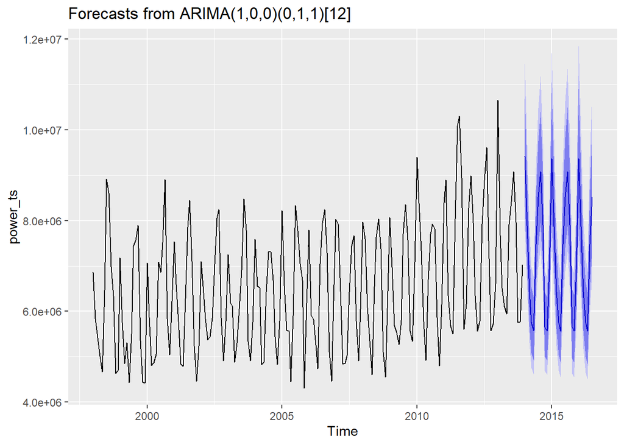

```r
power_ts_arima_fit%>% forecast(h=31) %>% autoplot()
```

```r
kpss.test(resid(power_ts_arima_fit))
```

```
##
##  KPSS Test for Level Stationarity
##
## data:  resid(power_ts_arima_fit)
## KPSS Level = 0.32902, Truncation lag parameter = 4, p-value = 0.1
```

### Box-Cox Holt-Winters Model

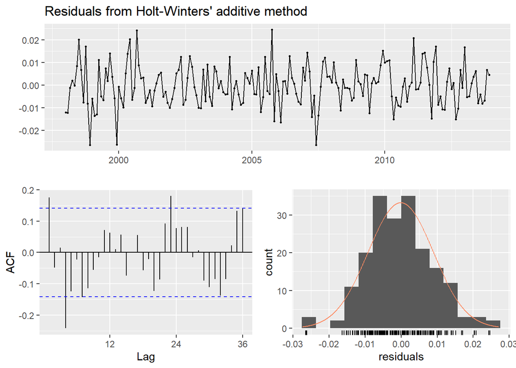

```
##
##  Ljung-Box test
##
## data:  Residuals from Holt-Winters' additive method
## Q* = 48.973, df = 8, p-value = 6.433e-08
##
## Model df: 16.   Total lags used: 24
```

```r
power_ts <- tsclean(power_ts)
adj_hw_fit <- hw(power_ts, h = 12, lambda = power_ts_lambda)
checkresiduals(adj_hw_fit)
```

### MODEL EVALUATION

I will use the `tsCV` function and evaluate the models as I used for PART A.My goal is to find the model that produces minumum RMSE.

```r
h <- 12
get_rmse <- function(error) {
  sqrt(mean(error^2, na.rm = TRUE))
}

power_ts_arima_fit_forecast <- function(x, h) {
  forecast(Arima(x, order = c(1, 0, 0), seasonal = c(0, 1, 1), lambda = power_ts_lambda), h = h)
}

residuals_hw <- tsCV(power_ts, hw, h = h)
residuals_arima <- tsCV(power_ts, power_ts_arima_fit_forecast, h = h)
data.frame(Model_Name = c("Holt-Winters", "ARIMA"),
           RMSE = c(get_rmse(residuals_hw[, h]), get_rmse(residuals_arima[, h]))) %>%
  arrange(RMSE) %>%
  kable() %>%
  kable_styling()
```

| Model_Name | RMSE |
| --- | --- |
| ARIMA | 703989.5 |
| Holt-Winters | 1010721.9 |

The ARIMA(1, 0, 0)(0, 1, 1) model gives the minumum RMSE among the other model.

### SUMMARY

Since Arima Model gives better RMSE result, I will use ARIMA model for forecasting purposes.

```r
power_ts_forecast <-power_ts_arima_fit %>% forecast(h=12)
power_forecast_df <-data_frame(DATE = paste0(2014, "-", month.abb), POWER_KWH = power_ts_forecast$mean)
power_forecast_df %>%
  kable() %>%
  kable_styling()
```

| DATE | POWER_KWH |
| --- | --- |
| 2014-Jan | 9417011 |
| 2014-Feb | 7893327 |
| 2014-Mar | 6436805 |
| 2014-Apr | 5756614 |
| 2014-May | 5570785 |
| 2014-Jun | 7479484 |
| 2014-Jul | 8522770 |
| 2014-Aug | 9080593 |
| 2014-Sep | 7909745 |
| 2014-Oct | 5661778 |
| 2014-Nov | 5568654 |
| 2014-Dec | 6919608 |

```r
write_csv(power_forecast_df,"power_forecast_df.csv")
```

## Part C - BONUS, optional (part or all)

Part C consists of two data sets. These are simple 2 columns sets, however they have different time stamps. Your optional assignment is to time-base sequence the data and aggregate based on hour (example of what this looks like, follows). Note for multiple recordings within an hour, take the mean. Then to determine if the data is stationary and can it be forecast. If so, provide a week forward forecast and present results via Rpubs and .rmd and the forecast in an Excel readable file.

### Data Engineering

```r
colnames(water1_data)= c("w1_date_time","WaterFlow")
colnames(water2_data)= c("w2_date_Time","WaterFlow")
water_df= water1_data %>% mutate(w2_date_Time = lubridate::round_date(w1_date_time,"hour") ) %>% select(w2_date_Time,WaterFlow) %>% bind_rows(water2_data) %>% group_by(w2_date_Time) %>% summarize(WaterFlowF = mean(WaterFlow, na.rm = T))
colnames(water_df)= c("Date_Time","WaterFlow")
water_ts = ts(water_df$WaterFlow,frequency = 24)
```

### Data Graphs

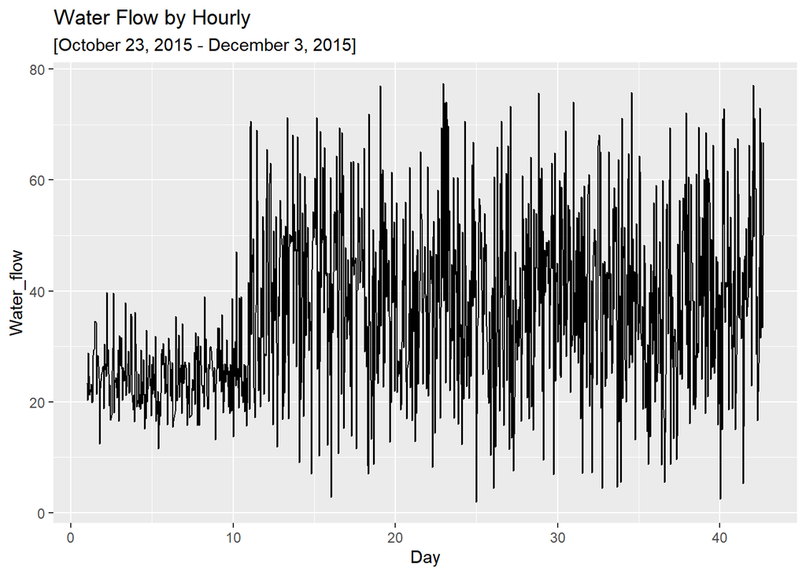

```r
autoplot(water_ts) +
  labs(title = "Water Flow by Hourly", subtitle = "[October 23, 2015 - December 3, 2015]", x = "Day", y = "Water_flow")
```

It is clear that data shows a lot of high and low as outliers or shocks.The variance of data also seems like not constant.

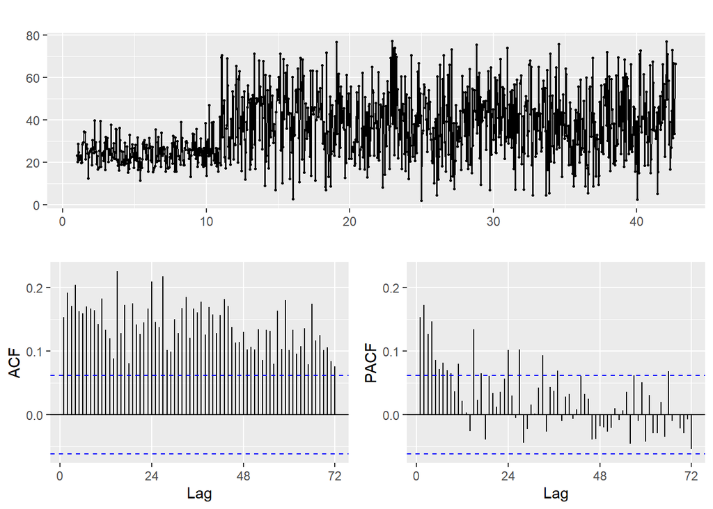

```r
ggtsdisplay(water_ts)
```

### Model Creation

I will use following forecating models on this time series and determine which one is better by estimatin error metric RMSE. I will use time series cross validation function to estimate RMSE for timeseries data.

#### ARIMA

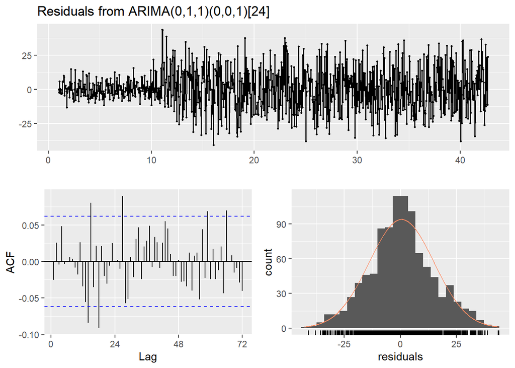

```
##
##  Ljung-Box test
##
## data:  Residuals from ARIMA(0,1,1)(0,0,1)[24]
## Q* = 67.6, df = 46, p-value = 0.02068
##
## Model df: 2.   Total lags used: 48
```

```r
water_ts_arima_fit <- auto.arima(water_ts)
checkresiduals(water_ts_arima_fit)
```

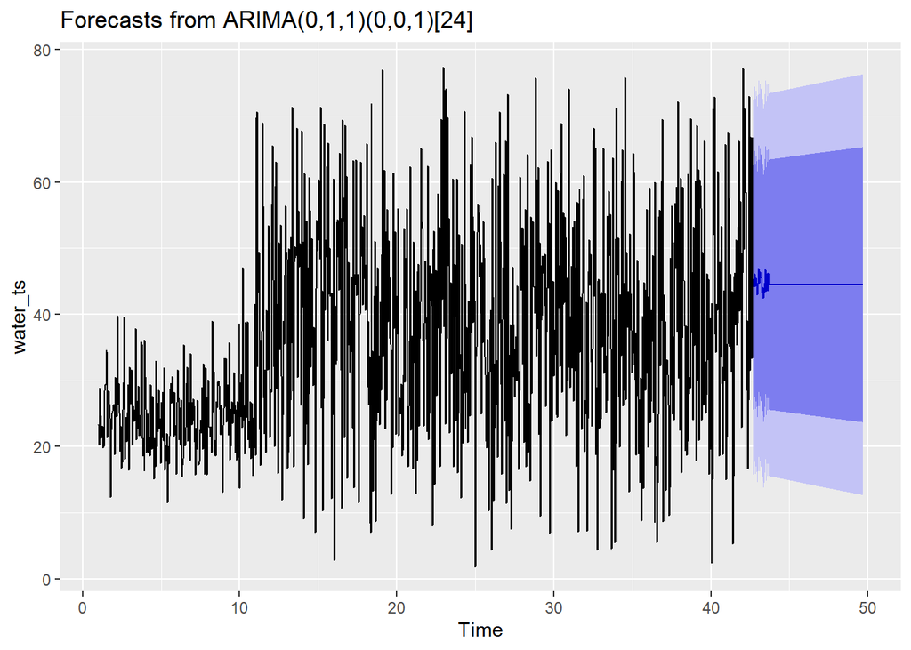

```r
water_ts_arima_fit%>% forecast(h=168) %>% autoplot()
```

```r
kpss.test(resid(water_ts_arima_fit))
```

```
##
##  KPSS Test for Level Stationarity
##
## data:  resid(water_ts_arima_fit)
## KPSS Level = 0.076651, Truncation lag parameter = 7, p-value = 0.1
```

### ARIMA with Box Cox Adjustment

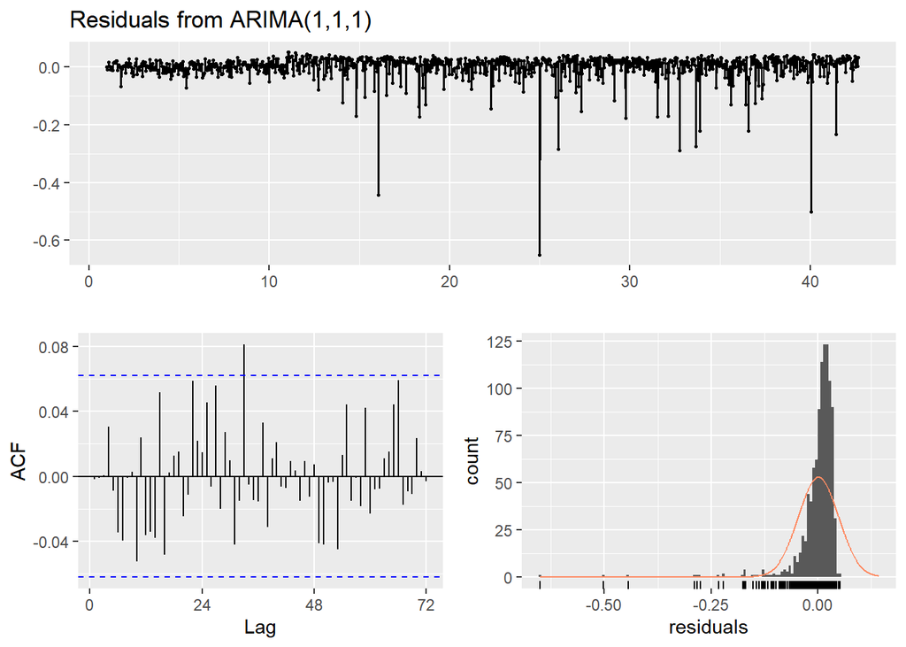

```
##
##  Ljung-Box test
##
## data:  Residuals from ARIMA(1,1,1)
## Q* = 41.128, df = 46, p-value = 0.6761
##
## Model df: 2.   Total lags used: 48
```

```r
water_ts_lambda = BoxCox.lambda(water_ts)
water_ts_box_arima_fit <- Arima(water_ts, order=c(1, 1, 1),lambda = water_ts_lambda)
checkresiduals(water_ts_box_arima_fit)
```

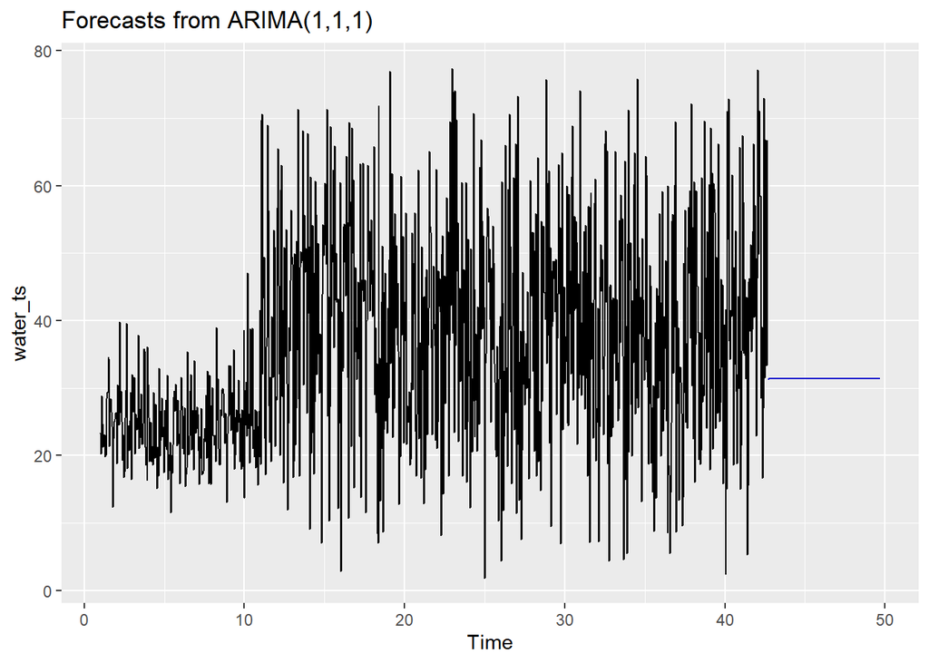

```r
water_ts_box_arima_fit%>% forecast(h=168) %>% autoplot()
```

```r
kpss.test(resid(water_ts_box_arima_fit))
```

```
##
##  KPSS Test for Level Stationarity
##
## data:  resid(water_ts_box_arima_fit)
## KPSS Level = 0.087414, Truncation lag parameter = 7, p-value = 0.1
```

### MODEL EVALUATION

I will use the `tsCV` function and evaluate the models as I used for PART A and PART B.My goal is to find the model that produces minumum RMSE.

```r
h <- 168
get_rmse <- function(error) {
  sqrt(mean(error^2, na.rm = TRUE))
}

water_ts_arima_fit_forecast <- function(x, h) {
  forecast(Arima(x, order = c(0, 1, 1),seasonal = c(0, 0, 1)), h = h)
}

water_ts_arima_box_fit_forecast <- function(x, h) {
  forecast(Arima(x, order=c(1, 1, 1), lambda = water_ts_lambda), h = h)
}


''
```

```
## [1] ""
```

```r
residuals_arima<- tsCV(water_ts,water_ts_arima_fit_forecast, h = h)
residuals_arima_box <- tsCV(water_ts, water_ts_arima_box_fit_forecast, h = h)
data.frame(Model_Name = c("ARIMA", "ARIMA_BOX_COX"),
           RMSE = c(get_rmse(residuals_arima[, h]), get_rmse(residuals_arima_box[, h]))) %>%
  arrange(RMSE) %>%
  kable() %>%
  kable_styling()
```

| Model_Name | RMSE |
| --- | --- |
| ARIMA | 17.36650 |
| ARIMA_BOX_COX | 18.82279 |

### SUMMARY

The ARIMA and ARIMA with Box_COX transformation model results are pretty close.However, Since Arima gives minumum value in RMSE result, I will use ARIMA(0,1,1)(0,0,1) model for forecasting purposes.

```r
water_forecast<-water_ts_arima_fit %>% forecast(h=168)
water_forecast_df <- data.frame(water_forecast$mean)
colnames(water_forecast_df) <- "water_flow"
row.names(water_forecast_df) <- seq(ymd_hm("2015-12-3 17:00"), ymd_hm("2015-12-10 16:00"), by = "hour")
kable(water_forecast_df)
```

|  | water_flow |
| --- | --- |
| 2015-12-03 17:00:00 | 44.10568 |
| 2015-12-03 18:00:00 | 45.27422 |
| 2015-12-03 19:00:00 | 46.18329 |
| 2015-12-03 20:00:00 | 44.17254 |
| 2015-12-03 21:00:00 | 45.49246 |
| 2015-12-03 22:00:00 | 44.69631 |
| 2015-12-03 23:00:00 | 42.99370 |
| 2015-12-04 00:00:00 | 44.72864 |
| 2015-12-04 01:00:00 | 46.97255 |
| 2015-12-04 02:00:00 | 44.73431 |
| 2015-12-04 03:00:00 | 46.39813 |
| 2015-12-04 04:00:00 | 45.59040 |
| 2015-12-04 05:00:00 | 45.52474 |
| 2015-12-04 06:00:00 | 43.32449 |
| 2015-12-04 07:00:00 | 44.10577 |
| 2015-12-04 08:00:00 | 42.42523 |
| 2015-12-04 09:00:00 | 43.14329 |
| 2015-12-04 10:00:00 | 44.67196 |
| 2015-12-04 11:00:00 | 46.79987 |
| 2015-12-04 12:00:00 | 43.47161 |
| 2015-12-04 13:00:00 | 46.13864 |
| 2015-12-04 14:00:00 | 44.38329 |
| 2015-12-04 15:00:00 | 43.58102 |
| 2015-12-04 16:00:00 | 46.20608 |
| 2015-12-04 17:00:00 | 44.46400 |
| 2015-12-04 18:00:00 | 44.46400 |
| 2015-12-04 19:00:00 | 44.46400 |
| 2015-12-04 20:00:00 | 44.46400 |
| 2015-12-04 21:00:00 | 44.46400 |
| 2015-12-04 22:00:00 | 44.46400 |

[output cut: 138 more lines]

```r
write.csv(water_forecast_df,"water_flow_forecast.csv")
```